# LCAT Activity Assay

Brian

6/16/2021

## Objective

To compare lecithin-cholesterol acyltransferase (LCAT) activity by dose-response using ERCC plasma, ApoB-depleted plasma, and HDL.

## Method

### Samples

*Note*: 2.5 and 25 ug HDL protein is equivalent to 25 ug/ml and 250 ug/ml, respectively.

### Detailed method

LCAT activity was measured using a validated fluorometric kit (Roar Biomedical, NY, USA), as per manufacturer’s instructions. LCAT activity was read fluorometrically at 390 nm and 470 nm and expressed as a ratio of the two. These two wavelengths represent the LCAT substrate hydrolysed and not hydrolysed. An increase in the ratio indicates increased LCAT activity.

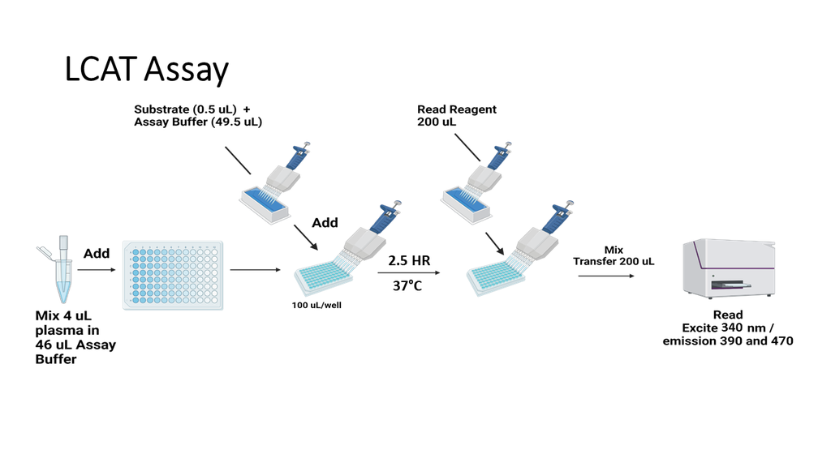

## Bar Graph

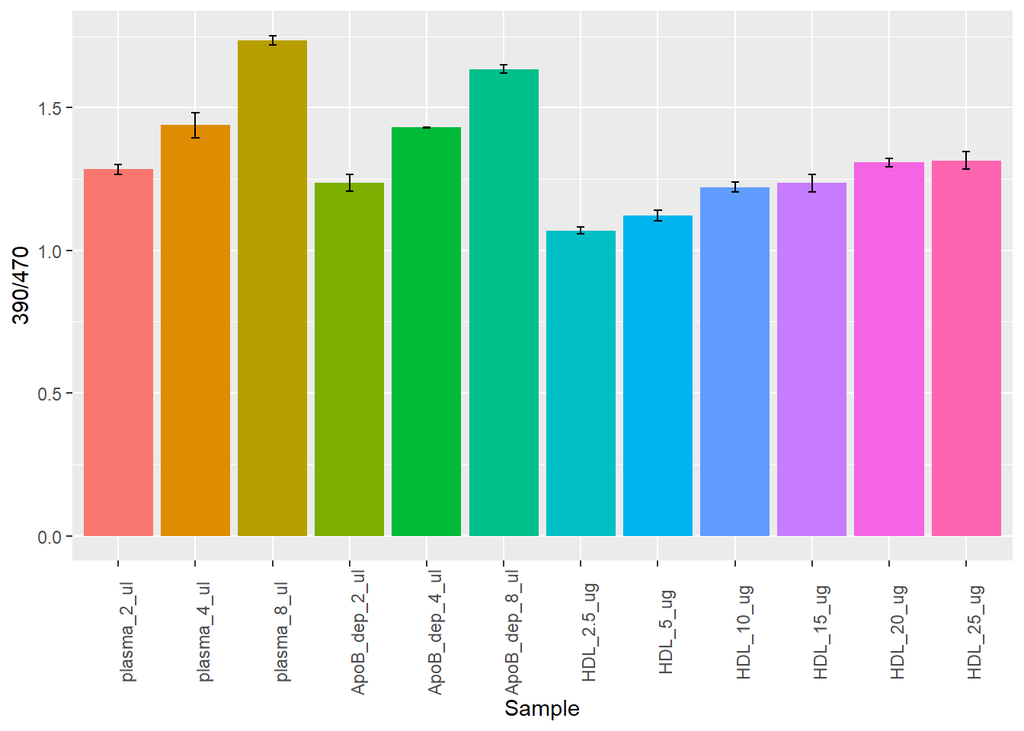

## CV

|  | Sample | Mean (390/470 ratio) | SD | CV (%) |
| --- | --- | --- | --- | --- |
| 1 | ApoB_dep_2_ul | 1.23603795421798 | 0.0288194011656947 | 0.0233159516399545 |
| 2 | ApoB_dep_4_ul | 1.43061711651305 | 0.00204666463591874 | 0.00143061662851289 |
| 3 | ApoB_dep_8_ul | 1.63497123254383 | 0.0151429578078856 | 0.00926191085596343 |
| 4 | HDL_10_ug | 1.22116369545217 | 0.0173077129339172 | 0.0141731309228847 |
| 5 | HDL_15_ug | 1.23611394243232 | 0.0311090734413854 | 0.025166833229121 |
| 6 | HDL_2.5_ug | 1.06998165335474 | 0.0114088724538751 | 0.0106626804470007 |
| 7 | HDL_20_ug | 1.30787368787365 | 0.0150078083917025 | 0.0114749677517424 |
| 8 | HDL_25_ug | 1.31508973741778 | 0.0300071468196457 | 0.0228175659545223 |
| 9 | HDL_5_ug | 1.1221061287665 | 0.0179020763715395 | 0.0159539957162687 |
| 10 | plasma_2_ul | 1.28439493467162 | 0.0169647870188016 | 0.0132083882930751 |

[output cut: 2 more lines]

## Summary

LCAT activity increased in a dose-response manner for all samples. Plasma and ApoB-depleted plasma showed similar trends. Although LCAT activity of HDL was lowest, increasing incubation time may help maximize signal.